# Continuous Probability

April 16, 2020

## Chapter 6

**Section 6.1 through Section 6.2**

### Continuous Probability

Thus far have studied distributions with finite or countably infinite support.

Consider studying a *continuous* random variable that takes on an uncountable, continuum, of outcomes.

*Example.*

Let \( \small X \) be the reaction time in seconds to a given stimulus.

- Theoretically, the possible outcomes are all positive real values.
- In practice, we will observe rounded values (rounded to milliseconds).

Need a new type of function to properly understand continuous random variables.

## Cumulative Distribution Function

*Definition.*

The **cumulative distribution function** or **cdf** of a random variable \( \small X \) is denoted by \( \small F_X(x) \) and given by

\[ F_X(x) = P(X \leq x) \quad \text{ for all real values x} \]

*Note.*

This definition is for every random variable, not just continuous!

### Discrete cdf Example

Let \( \small X \sim HyperG(N = 10, r = 4, n = 3) \). Then,

\[ p(x) = \frac{{4 \choose x}{6 \choose 3-x}}{{10 \choose 3}} \quad \text{ for } x = 0, 1, 2, 3 \]

*Notice this is a case where \( x_{max} < r \), another unique case for the HyperG distribution.*

We can study this distribution with a table. Here I give three rows, the first representing the observed outcome \( \small x \). The second shows the values of the pmf, or the probability of observing the values \( \small x \). Remember this is a discrete case as we have studied, so the probabilities are given by the pmf. The third row accumulates the probabilities as \( \small x \) increases; this gives us the cumulative probabilities for \( \small X \), denoted \( \small F_X(x) \).

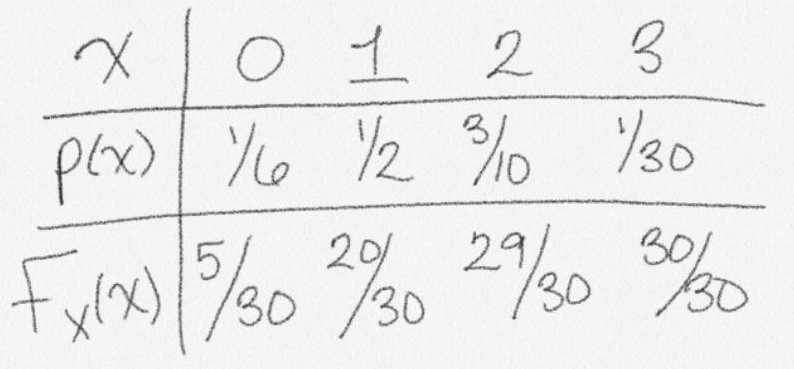

Notice the cdf gives the sum of all probabilities up to an included the observed \( \small x \). For *discrete* we find this with

\[ F_X(2) = P(X \leq 2) = p(0) + p(1) + p(2) = \frac{1}{6} + \frac{1}{2} + \frac{3}{10} = \frac{29}{30} \]

### Discrete cdf Example Continued

Notice that we find the CDF by finding the probabilities accumulated up to and including \( \small x \).

For *discrete* distributions this created steps. Here is the cdf as a piecewise function.

\[ F_X(x) = \large \begin{cases} 0 &\quad x < 0 \\ \frac{5}{30} &\quad 0 \leq x < 1 \\ \frac{20}{30} &\quad 1 \leq x < 2 \\ \frac{29}{30} &\quad 2 \leq x < 3 \\ 1 &\quad x \geq 3 \end{cases} \]

Notice that the equalities are placed such that the probabilities 'jumps' as we reach the next observable outcome. This can be graphed.

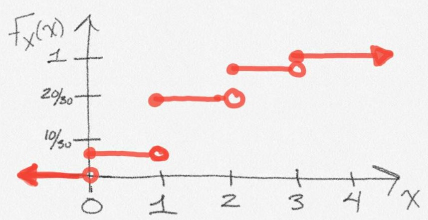

### CDF Properties

There are key properties that must hold for a function to be considered a cdf.

### Properties of a cdf:

(1)

\[ \lim\limits_{x \to -\infty} F_X(x) = 0 \]

(2)

\[ \lim\limits_{x \to \infty} F_X(x) = 1 \]

(3)

\( \small F_X(x) \) is **non-decreasing** as a function of \( \small x \).

- If \( \small x_1 < x_2 \), then \( \small F(x_1) \leq F(x_2) \).

(1)

\( \small F_X(x) \) is **right-continuous**

\[ \lim\limits_{x \to a^+} F_X(x) = F(a^+) = F(a) \]

## Continuous Random Variable

*Definition.*

\( \small X \) is a **continuous random variable** if the cumulative distribution function of \( \small X \), \( \small F(x) \), is continuous for all real values \( \small x \).

### Example of a Continuous Random Variable

Let \( \small X \) be a random variable with the cdf

\[ F_X(x) = \begin{cases} 0 & \quad x < 0 \\ x & \quad 0 \leq x < 1 \\ 1 & \quad x \geq 1 \end{cases} \]

\( \small F(x) \) is continuous for all real values of \( \small x \), thus the random variable \( \small X \) is continuous.

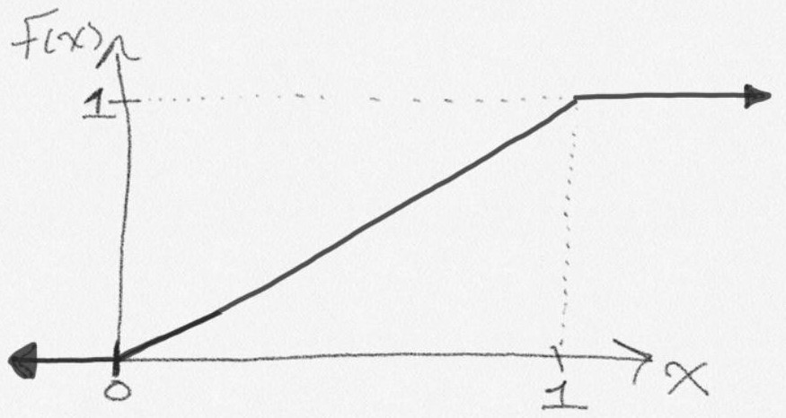

*Note.*

For continuous random variables there are no jump-points (steps) in the cdf.

*Note.*

For a continuous random variable \( \small P(X = x_0) = 0 \) for any real valued number \( \small x_0 \).

### Example Continued

\[ F_X(x) = \begin{cases} 0 & \quad x < 0 \\ x & \quad 0 \leq x < 1 \\ 1 & \quad x \geq 1 \end{cases} \]

Probability is not associated with a number, such as in the discrete case. For continuous random variables, we associate probaility with an **interval**.

### Probability \( \small X \) is less than or equal to 0.75

\[ P(X \leq 0.75) = F_X(0.75) = 0.75 \]

This is equivalent to fidning \( \small P(x \in (-\infty, 0.75]) \)

### Probability \( \small X \) is between 1/3 and 9/8

\[ P(1/3 \leq X \leq 9/8) = F_X(9/8) - F_X(1/3) = 1 - 1/3 = 2/3 \]

## Probability density function (pdf)

*Definition.*

For a continuous random variable, \( \small X \), the **probability density function (pdf)** of \( \small X \) is denoted \( \small f_X(x) \) and given by

\[ f_X(x) = \frac{d}{dx}F_X(x) = F^{'}_X(x) \]

provided that the derivative exists.

*Note.*

Baesd on the definitions of \( \small F_X(x) \) and \( \small f_X(x) \), we have that

\[ F_X(x) = \int\limits_{-\infty}^{x}f_X(x)dx = P(X \leq x) \]

The probability of a continuous random variable is associated with the area under the curve.

### Return to Example

### CDF

\[ F_X(x) = \begin{cases} 0 & \quad x < 0 \\ x & \quad 0 \leq x < 1 \\ 1 & \quad x \geq 1 \end{cases} \]

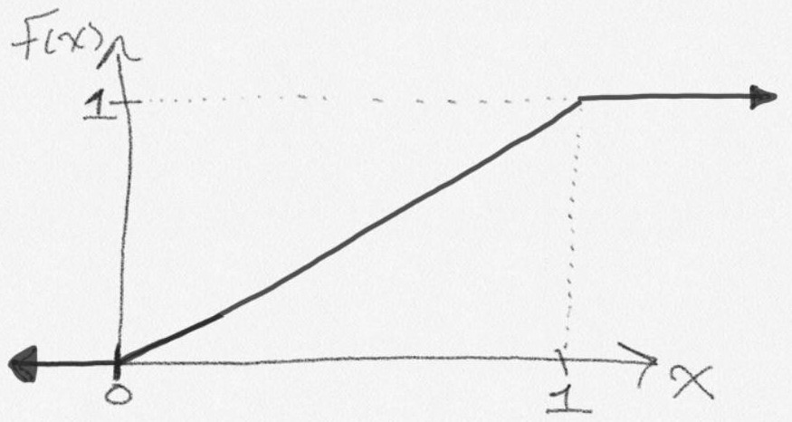

### PDF

\[ f_X(x) = F^{'}_X(x) = \begin{cases} 0 & \quad x < 0 \\ 1 & \quad 0 \leq x < 1 \\ 0 & \quad x \geq 1 \end{cases} \]

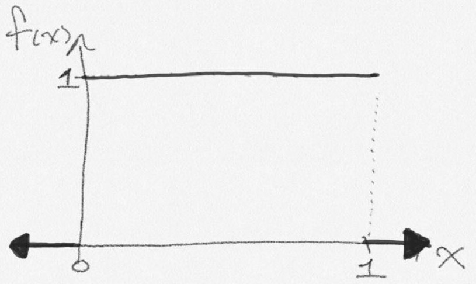

### Properties of a pdf

What properties must a function \( \small f_X(x) \) have to be the pdf of a continuous random variable, \( \small X \)?

(1)

\( \small F_X(x) \) is non-decreasing, thus \( \small f_X(x) \) must be non-negative.

(2)

Because \( \small \lim\limits_{x\to\infty} F_X(x) = 1 \), thus \( \small f_X(x) \) must integrate to \( \small 1 \).

This gives us important results that relate back to our probability axioms.

## Probability density function

*Result.*

If \( \small f(x) \) is the pdf of a continuous random variable, \( \small X \), then

(1)

\[ f(x) \geq 0 \text{ for any real value }x \]

(2)

\[ \int\limits_{-\infty}^{\infty}f(x)dx = 1 \]

*Note.*

This extends our axioms to continuous random variables.

## Probability from a pdf

*Result.*

For a continuous random variable, \( \small X \), with pdf, \( \small f(x) \), and \( \small a \leq b \),

\[ \begin{aligned} P(a \leq X \leq b) &= F(b) - F(a) \\ &= \int\limits_{-\infty}^{b}f(x)dx - \int\limits_{-\infty}^{a}f(x)dx\\ \therefore P(a \leq X \leq b) &= \int\limits_{a}^{b}f(x)dx \end{aligned} \]

*Note.* The pdf does not give probabilities. Probability is found by integrating the pdf.

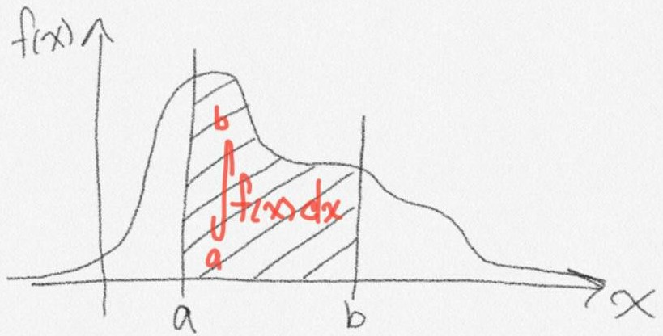

### Continuous Probability Example

Suppose \( \small X \) is a random variable with pdf

\[ f(x) = cx(1-x)1_{(0,1)}(x) \]

### Find c and graph the pdf

Use that to be a pdf, integration over the entire real line must equate to 1.

\[ \begin{aligned} 1 &= \int\limits_{-\infty}^{\infty}f(x)dx = \int\limits_{-\infty}^{\infty}cx(1-x)1_{(0,1)}(x) \\ &= \int\limits_{-\infty}^{0}0dx + \int\limits_{0}^{1}cx(1-x)dx + \int\limits_{1}^{\infty}0dx \end{aligned} \]

This redistributes the integral into a sum over the support, \( (0,1) \), and outside the support must be \( 0 \) by definition. Then,

\[ \begin{aligned} 1 &=\int\limits_{0}^{1}cx(1-x)dx =c\left.\left(\frac{x^2}{2} - \frac{x^3}{3}\right)\right|_{0}^{1} \\ &= c\left(\frac{1}{2} - \frac{1}{3}\right) = \frac{c}{6} \quad \therefore \quad c = 6 \end{aligned} \]

### Example Continued

Thus, we have that \( f(x) = 6x(1-x)1_{(0,1)}(x) \). It can be helpful to visualize the pdfs.

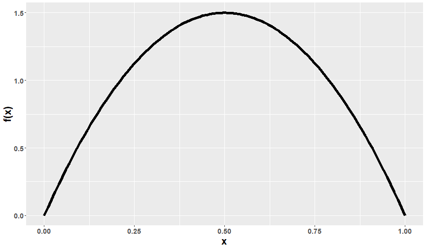

This function obtains a maximum and is symmetric around \( x = 1/2 \), where the density is, \( f(1/2) = 3/2 \).

### Is this a valid pmf?

(1) Integrates to 1.

(2) Is non-negative for all real values of \( x \).

Thus, this is a valid pmf for a continuous random variables \( \small X \).

### Example Continued

### Find \( \small P(X > 1/2) \).

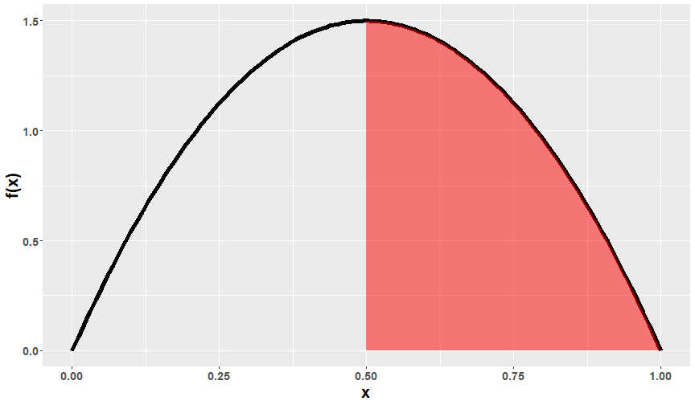

This function is symmetric around \( \small x = 1/2 \), thus \( \small P(X > 1/2) = P(X < 1/2) = 1/2 \).

### Example Continued

What about the probability we see an \( \small x \in [1/4, 3/4] \).

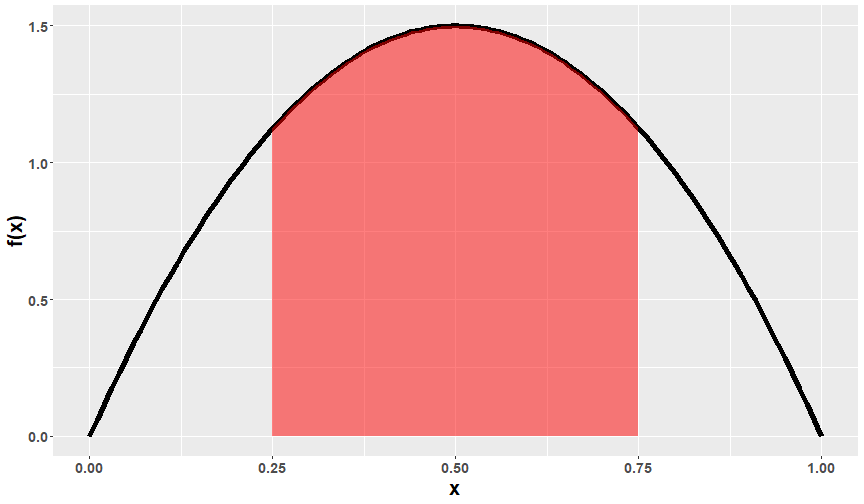

### Find P(¼ < X < ¾)

\[ \begin{aligned} P(1/4 < X < 3/4) &= \int\limits_{1/4}^{3/4}f(x)dx = \int\limits_{1/4}^{3/4}6x(1-x)dx \\ &= 6\left.\left(\frac{x^2}{2}-\frac{x^3}{3}\right)\right|_{1/4}^{3/4} = \frac{27}{32} - \frac{5}{32} = \frac{22}{32} = 0.6875 \end{aligned} \]

### Example Continued

### Find \( \small x^* \) such that \( F(x^*) = 3/4 \).

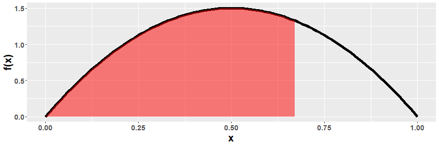

This is known as the *third quantile*, where \( 75\% \) of the outcomes \( x \) are less than \( x^* \). Recall,

\[ \begin{aligned} F(x) &= P(X \leq x) = \int\limits_{-\infty}^{x}f(t)dt =\begin{cases} 0 & x \leq 0 \\ \int\limits_{0}^{x}6t(1-t)dt & 0 < x < 1 \\ 1 & x \geq 1 \end{cases} \end{aligned} \]

We need that

\[ \int\limits_{0}^{x}6t(1-t)dt = 6\left.\left(\frac{t^2}{2}-\frac{t^3}{3}\right)\right|_{0}^x = 3x^2 - 2x^3 \]

We want to find \( \small F(x^*) = 3(x^*)^2 - 2(x^*)^3 = 3/4 \). Best to solve numerically,

\[ F(x^*) = 3/4 \implies x^* \approx 0.6736 \]